# kommunrapport_master

## Hälsoförutsättningar och riskfaktorer

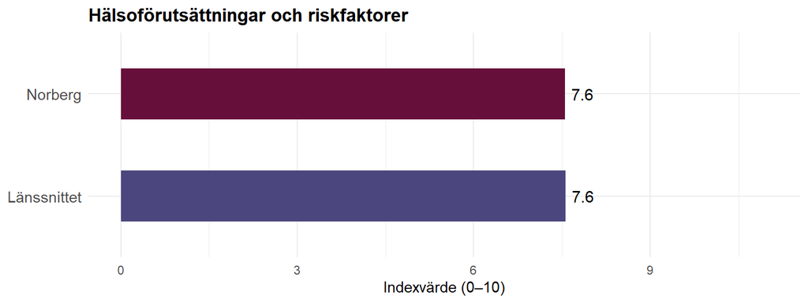

Diagram 31. Indexvärde för Hälsoförutsättningar och riskfaktorer jämfört med länssnittet.

Resultatet för Norberg visar en nivå i linje med länsgenomsnittet på området Hälsoförutsättningar och riskfaktorer (7.6 jämfört med 7.6), vilket innebär att kommunen följer det övergripande mönstret i länet.

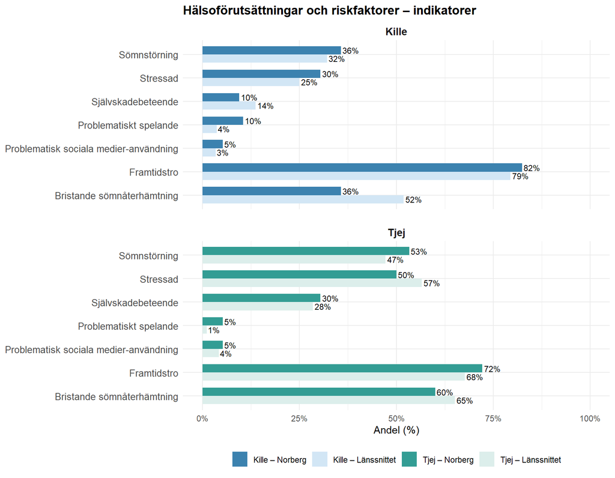

Diagram 32. Indikatorer inom Hälsoförutsättningar och riskfaktorer - andel per kön jämfört med länssnittet

Tabell 16. Indikatorer inom Hälsoförutsättningar och riskfaktorer – kommunens värde jämfört med länssnittet.

| Indikator | Kommun (%) | Länssnittet (%) | ± % | Jämfört med länet |
| --- | --- | --- | --- | --- |
| Bristande sömnåterhämtning | 48 | 59 | -10 | ▼ Lägre |
| Problematiskt spelande | 8 | 2 | 6 | ▲ Högre |
| Sömnstörning | 45 | 40 | 5 | ▲ Högre |
| Framtidstro | 77 | 73 | 4 | ▲ Högre |
| Problematisk sociala medier-användning | 5 | 4 | 2 | ▲ Högre |
| Stressad | 40 | 41 | -1 | ▼ Lägre |
| Självskadebeteende | 20 | 21 | -1 | ▼ Lägre |

Norbergs övergripande resultat för området Hälsoförutsättningar och riskfaktorer är i nivå med länets, men på indikatornivå finns skillnader i varierande riktningar. Andelen killar med bristande sömnåterhämtning är 16 procentenheter lägre än bland killar i länet. Samtidigt är problematiskt spelande vanligare bland killar i Norberg, med en andel som är mer än dubbelt så hög som i länet, och även stress är något vanligare. Bland tjejer är andelen som känner sig stressade 7 procentenheter lägre än i länet, medan sömnstörningar är något vanligare. Övriga indikatorer ligger nära länets nivå för både tjejer och killar. Med tanke på den låga svarsfrekvensen bör resultaten tolkas med försiktighet (se avsnittet Deltagande och svarsfrekvens).

# Sambandsanalys

## Begreppsförklaring

**Beta (sambandsstyrka)** visar hur starkt en faktor hänger samman med ungas mående. Värdet kan variera mellan −1 och 1. Ett högre positivt värde innebär ett starkare samband mellan gynnsamma förhållanden och bättre mående. Ett negativt värde innebär att sambandet går i motsatt riktning.

**LMG (relativ förklaringskraft)** visar hur stor del av modellens förklarade variation i mående som kan tillskrivas varje område eller indikator när samtliga faktorer beaktas. Metoden tar hänsyn till att faktorer kan överlappa och delar då den gemensamma förklaringskraften mellan dem. Ett högre LMG-värde innebär att faktorn står för en större del av modellens samlade förklaringskraft.

## Analysmetod

Sambandsanalysen undersökte vilka områden och indikatorer som hade starkast samband med ungas allmänna mående, baserat på samtliga svarande i länet. Resultaten är därför desamma i alla kommunrapporter. Analysen genomfördes i flera steg med linjär regressionsanalys. Samtliga regressionsanalyser justerades för kön och årskurs, som tillsammans förklarade 8,3 procent av variationen i allmänt mående.

Först analyserades vart och ett av de fjorton områdena separat för att undersöka sambandets styrka och riktning. Detta gav en övergripande bild av vilka delar av ungas livssituation som hade starkast samband med måendet.

Därefter analyserades samtliga områden samtidigt. Eftersom flera områden mäter närliggande delar av ungas livssituation gjorde detta det möjligt att undersöka respektive områdes samband med mående när hänsyn togs till övriga områden. För de fjorton områdena genomfördes även en relativ viktanalys (LMG), som visade hur stor del av modellens samlade förklaringskraft som kunde tillskrivas respektive område.

Som komplement genomfördes överlappningsanalyser mellan områden med hög inbördes korrelation för att undersöka hur stor del av deras förklaringskraft som var gemensam. Resultaten från dessa analyser redovisas i Bilaga B.

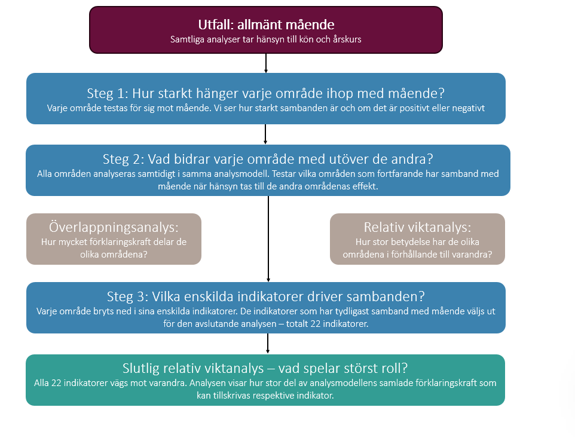

## Resultat på områdesnivå

Diagram 33 visar att Hälsoförutsättningar och riskfaktorer tydligt skiljer ut sig genom att kombinera ett mycket starkt samband med mående och den största förklaringskraften. Att Hälsoförutsättningar och riskfaktorer behåller en så stor andel av den förklarade variansen tyder på att området fångar aspekter av ungas mående som inte fullt ut fångas av de övriga områdena.

Socialt stöd och ensamhet har också ett starkt samband med mående men ett betydligt mindre bidrag till den förklarade variansen, vilket visar att en del av sambandet delas med andra områden. Skolmiljö och stöd samt Trygghet bidrar med både relativt starka och självständiga samband.

Flera områden, såsom Föräldrarelation, Tillit och förtroende, Levnadsvillkor och Utsatthet, har relativt starka samband med mående men ett begränsat bidrag till förklaringsgraden. Det tyder på att en stor del av deras samband delas med andra områden.

Delaktighet är det enda området med ett negativt samband (Beta=-0,11). Det negativa sambandet bör inte tolkas som att delaktighet orsakar sämre mående. En möjlig förklaring är att unga som mår sämre i högre grad engagerar sig i samhällsfrågor

Flera områden överlappar delvis i vad de mäter, det är väntat eftersom de mäter närliggande delar av ungas livssituation, och innebär inte att de är oviktiga.

*Analyserna är justerade för kön och årskurs, och de förklarar tillsammans omkring 8 % av variansen i mående.*

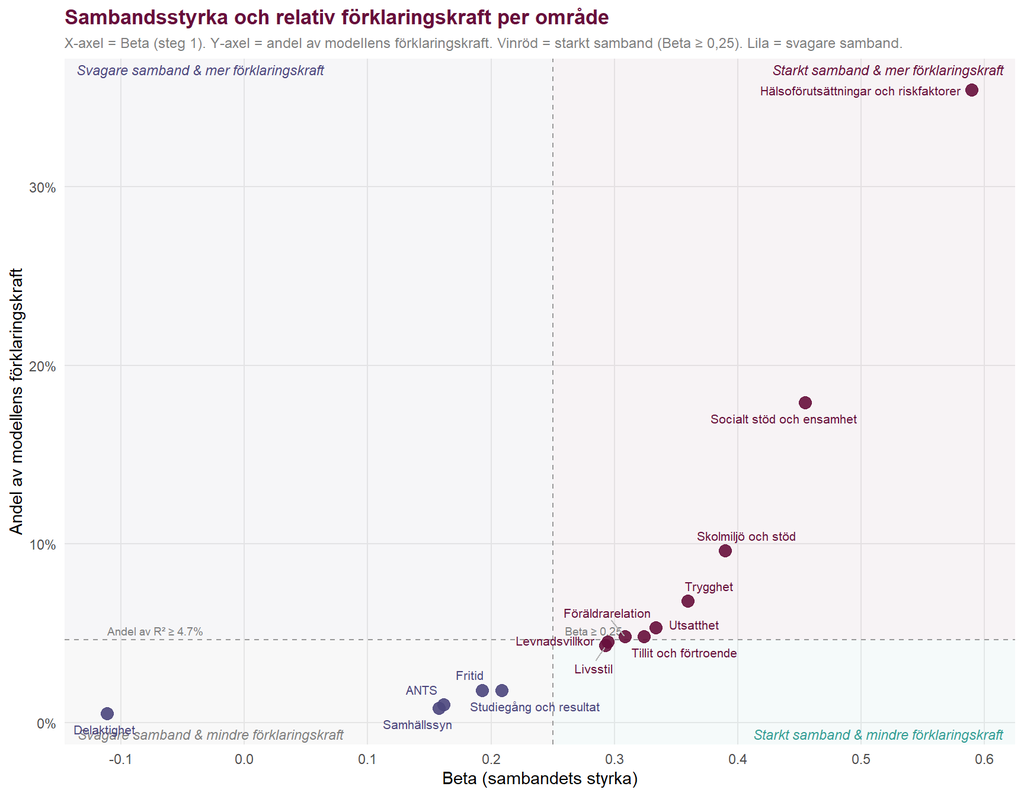

Diagram 33. Sambandsstyrka och relativ vikt per område - Beta (Steg 1) och LMG.

**Hur läser man diagrammet?**

Varje punkt representerar ett område. Ju längre åt höger ett område ligger, desto starkare är sambandet med ungas mående (Beta). Ju högre upp det ligger, desto större andel av modellens förklaringskraft står området för.

Områden i det övre högra hörnet har både ett starkt samband med mående och stor relativ förklaringskraft. Områden långt till höger men längre ned har också starka samband, men står för en mindre del av modellens samlade förklaringskraft. Beräkningen av den relativa förklaringskraften bygger på LMG, som tar hänsyn till att områden kan överlappa och fördelar den gemensamma förklaringskraften mellan dem.

Samtliga områden är kodade så att högre värden innebär mer gynnsamma förhållanden. Ett positivt Beta innebär därför att bättre förutsättningar inom området hänger samman med bättre mående.

De streckade linjerna är vägledande och används för att underlätta tolkningen. Beta 0,25 markerar starkare samband, medan den horisontella linjen visar medianen för områdenas andel av modellens förklaringskraft. Gränserna ska inte tolkas som skarpa gränser mellan viktiga och mindre viktiga områden.

Diagrammet visar därmed två kompletterande perspektiv: hur starkt varje område hänger samman med mående och hur stor relativ betydelse området har för modellens samlade förklaringskraft.

*Fullständiga resultat för samtliga områden redovisas i Bilaga A.*

## Resultat på indikatornivå

När varje område bryts ned på indikatornivå framträder en mer nyanserad bild av vad som konkret hänger ihop med ungas mående. Samtliga indikatorer är kodade så att högre värden motsvarar mer gynnsamma förhållanden, ett högt positivt Beta innebär att bättre förutsättningar inom indikatorn hänger samman med bättre mående.

Stress och Framtidstro sticker ut som de mest centrala indikatorerna (diagram 34), med både starka samband och stora bidrag till den förklarade variansen. Båda tillhör Hälsoförutsättningar och riskfaktorer, vilket visar att områdets starka samband med mående i hög grad drivs av hur unga upplever belastning från stress och sin framtid.

Skoltrivsel är en av de mer centrala indikatorerna utanför Hälsoförutsättningar, med högt bidrag till förklarad varians, och har även ett starkt samband med mående. Detta är särskilt intressant eftersom området Skolmiljö och stöd som helhet hade ett svagare samband med mående än Socialt stöd och ensamhet, medan skoltrivsel på indikatornivå bidrar med mer till den förklarade variansen än de enskilda sociala indikatorerna. Skoltrivsel samvarierar också med flera andra aspekter av skolmiljön, såsom studiero (r=0,36), lärarrelationer (r=0,39–0,41) och upplevd hjälp i skolan (r=0,46). Att dessa indikatorer har svagare självständiga samband i den gemensamma modellen kan delvis bero på att de delar förklaringskraft med skoltrivsel. Tillsammans med att upplevd trygghet i skolan är den starkaste indikatorn inom området trygghet understryker resultaten betydelsen av en trygg och trivsam skolmiljö för ungas mående.

Nöjdhet med fritiden uppvisar ett relativt starkt och självständigt samband med mående, tydligare än för deltagande i fritidsaktiviteter och möjligheten att delta i de aktiviteter man vill. De svaga korrelationerna mellan nöjdhet och dessa indikatorer (r=0,17 respektive r=0,23) tyder på att indikatorerna fångar delvis olika aspekter av ungas fritid. Vad som ligger bakom den upplevda nöjdheten kan dock inte avgöras utifrån analysen.

Ensamhet visar tydligt skillnaden mellan sambandsstyrka (Beta) och relativ betydelse (LMG). Ensamhet har det starkaste sambandet med mående av alla indikatorer, men står för en relativt liten del av den förklarade variansen i den gemensamma modellen. En förklaring är att ensamhet samvarierar med flera andra indikatorer. När dessa faktorer analyseras tillsammans delar de därför på en del av förklaringskraften. Ensamhet är alltså en viktig markör för hur unga mår, men en del av sambandet delas med andra delar av deras livssituation.

Självskadebeteende har ett svagare samband med allmänt mående än flera andra indikatorer. Samtidigt har självskadebeteende stor betydelse i den samlade analysen och står för en förhållandevis stor del av förklaringskraften. Det tyder på att självskadebeteende fångar något som inte redan fångas lika tydligt av de andra indikatorerna. Vad detta beror på går dock inte att avgöra utifrån analysen.

Även flera av de övriga indikatorerna har samband med mående, men sambanden är generellt svagare än för de mer framträdande indikatorerna. Deras relativa förklaringskraft varierar också. Resultaten bör därför inte tolkas som att dessa faktorer saknar betydelse, utan som att vissa indikatorer framträder tydligare än andra när sambandsstyrka och relativ förklaringskraft vägs samman.

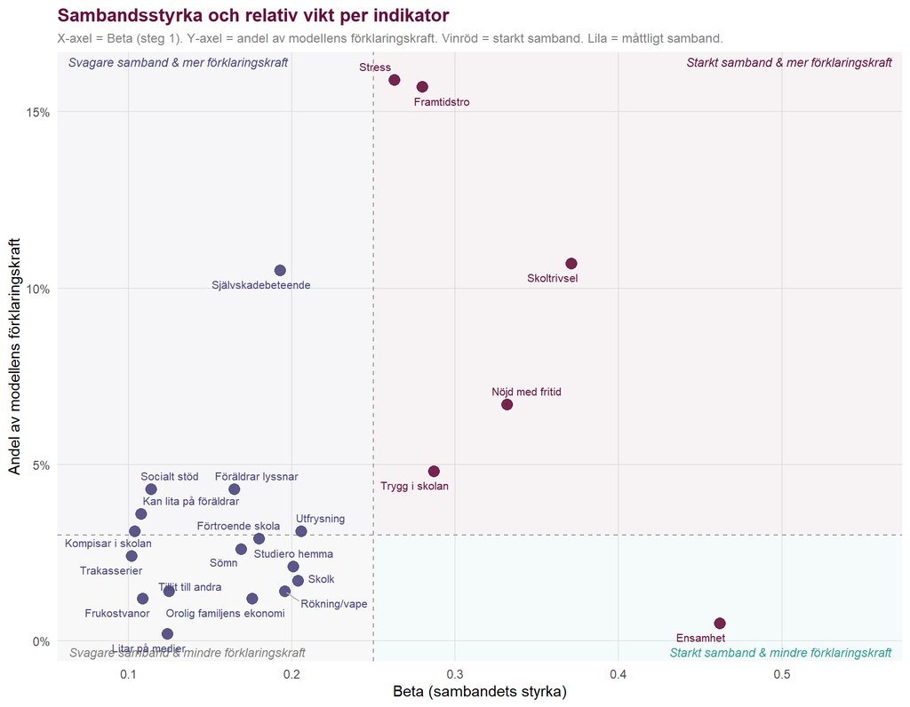

Diagram 34. Sambandsstyrka och relativ vikt per indikator - Beta (Steg 3) och LMG.

**Hur läser man diagrammet?** Varje punkt representerar en indikator. Ju längre åt höger en indikator ligger, desto starkare är sambandet med ungas mående (Beta). Ju högre upp den ligger, desto större andel av modellens förklaringskraft står indikatorn för.

Indikatorer i det övre högra hörnet har både ett starkt samband med mående och stor relativ förklaringskraft. Indikatorer långt till höger men längre ned har också starka samband, men står för en mindre del av modellens samlade förklaringskraft. Beräkningen av den relativa förklaringskraften bygger på LMG, som tar hänsyn till att indikatorer kan överlappa och fördelar den gemensamma förklaringskraften mellan dem.

Samtliga indikatorer är kodade så att högre värden innebär mer gynnsamma förhållanden. Ett positivt Beta innebär därför att bättre förutsättningar inom indikatorn hänger samman med bättre mående.

De streckade linjerna är vägledande och används för att underlätta tolkningen. Beta 0,25 markerar starkare samband, medan den horisontella linjen visar medianen för indikatorernas andel av modellens förklaringskraft. Gränserna ska inte tolkas som skarpa gränser mellan viktiga och mindre viktiga indikatorer.

Diagrammet visar därmed två kompletterande perspektiv: hur starkt varje indikator hänger samman med mående och hur stor relativ betydelse indikatorn har för modellens samlade förklaringskraft.

## Sammantagna slutsatser av sambandsanalys

Ungas mående hänger framför allt samman med psykisk belastning, framtidstro, skolmiljö och sociala relationer. Särskilt framträdande är stress, framtidstro, skoltrivsel, trygghet i skolan och nöjdhet med fritiden, som kombinerar relativt starka samband med stor relativ förklaringskraft.

Ett återkommande mönster är att ungas egna upplevelser av sin vardag, skola, relationer och framtid har starkare samband med mående än många mer yttre förutsättningar. Samtidigt överlappar flera faktorer med varandra, vilket innebär att deras betydelse inte alltid kan skiljas tydligt åt.

Resultaten visar samband, inte orsakssamband, och bör därför främst ses som vägledning för vilka områden som är viktiga att uppmärksamma snarare än som vad som orsakar bättre eller sämre mående.

Analysen baseras på samtliga respondenter i länet och resultaten är därför desamma i samtliga kommunrapporter. Sambandsanalysen genomfördes inte separat för varje kommun eftersom antalet svarande på kommunnivå ofta är för litet för att ge tillräckligt tillförlitliga resultat.

Resultatet av sambandsanalysen tillsammans med kommunen specifika resultat på områden och indikatorer kan ge vägledning för det främjande och förebyggande arbetet samt prioriteringar. Resultatet av sambandsanalysen pekar på betydelsen av att skapa förutsättningar för en trygg och trivsam skolmiljö, minska belastning från stress, och arbeta för att stärka ungas sociala relationer, framtidstro, och möjligheter till en meningsfull fritid. Eftersom många faktorer hänger samman och delvis överlappar varandra talar resultatet också för breda insatser som stärker flera delar av ungas livsvillkor och vardag.

# Om undersökningen

Liv och hälsa Ung är en webbaserad enkätundersökning som genomförs bland elever i årskurs 7 och 9 i grundskolan samt år 2 på gymnasiet. Undersökningen har genomförts regelbundet sedan 1995 och återkommer vart tredje år.

Undersökningen genomförs i samverkan mellan länets kommuner och andra regionala aktörer och syftar till att ge en återkommande bild av barn och ungas livsvillkor, hälsa och levnadsvanor över tid. Genom att använda en återkommande undersökning med liknande frågeområden skapas möjligheter att följa utvecklingen och identifiera förändringar mellan olika år.

## Syfte

Syftet med Liv och hälsa Ung är att öka kunskapen om barn och ungas livsvillkor, hälsa och levnadsvanor. Undersökningen omfattar frågor inom flera områden, exempelvis hälsa, levnadsvanor, sociala relationer, trygghet, skolmiljö och framtidssyn.

Resultaten utgör ett viktigt kunskaps- och beslutsunderlag för kommuner, regionen och andra aktörer i länet. Genom resultaten kan behov och utvecklingsområden identifieras, vilket kan bidra till mer välgrundade beslut om insatser och åtgärder riktade till barn och unga.

Resultaten används i flera olika sammanhang, exempelvis inom verksamhetsplanering, utvecklingsarbete, samverkan mellan aktörer och som underlag i projekt och ansökningar. Resultaten används även inom forskning och i vissa fall som pedagogiskt material i skolans verksamhet.

## Datainsamling

Datainsamlingen för 2026 års undersökning genomfördes under veckorna 4–8. Enkäten besvarades i skolmiljö och genomfördes vanligtvis under ledning av ansvarig lärare, mentor eller annan skolpersonal.

I 2026 års undersökning deltog 51 skolor, med totalt 8 386 elever i de aktuella årskurserna. Av dessa besvarade 6 687 elever enkäten, vilket gav en svarsfrekvens på 80%.

# Bilaga A – Fullständiga resultat på områdesnivå

Tabell 17. Sambandsanalys på områdesnivå — Beta, förklarad varians och relativ vikt (LMG) per område.

| Område | Enskilt samband Beta enskilt | Enskilt samband Förklarad varians (ΔR²) | Fullmodell Beta fullmodell | Fullmodell Signifikant i fullmodell | Relativ viktanalys LMG | Relativ viktanalys Andel av R² |
| --- | --- | --- | --- | --- | --- | --- |
| Hälsoförutsättningar och riskfaktorer | 0.590 | 31.3% | 0.390 | Ja | 0.140 | 35.4% |
| Socialt stöd och ensamhet | 0.455 | 20.1% | 0.198 | Ja | 0.071 | 17.9% |
| Skolmiljö och stöd | 0.390 | 14.5% | 0.087 | Ja | 0.038 | 9.6% |
| Trygghet | 0.360 | 10.9% | 0.074 | Ja | 0.027 | 6.8% |
| Utsatthet | 0.334 | 10.9% | 0.018 | Nej | 0.021 | 5.3% |
| Tillit och förtroende | 0.324 | 10.2% | 0.020 | Nej | 0.019 | 4.8% |
| Föräldrarelation | 0.309 | 9.4% | 0.019 | Nej | 0.019 | 4.8% |
| Levnadsvillkor | 0.295 | 8.6% | 0.019 | Nej | 0.018 | 4.5% |
| Livsstil | 0.293 | 7.8% | 0.046 | Ja | 0.017 | 4.3% |
| Studiegång och resultat | 0.209 | 4.3% | 0.005 | Nej | 0.007 | 1.8% |
| Fritid | 0.193 | 3.6% | 0.023 | Nej | 0.007 | 1.8% |
| ANTS | 0.162 | 2.3% | -0.015 | Nej | 0.004 | 1% |
| Samhällssyn | 0.158 | 2.3% | -0.016 | Nej | 0.003 | 0.8% |
| Delaktighet | -0.111 | 1.2% | 0.003 | Nej | 0.002 | 0.5% |

**Hur läser man tabellen?**

**Beta enskilt** – sambandsstyrkan när området analyseras för sig.

**Förklarad varians (ΔR²)** – hur stor del av skillnaderna i mående området förklarar när det analyseras för sig.

**Beta fullmodell** – sambandsstyrkan när alla områden analyseras samtidigt.

**LMG / Andel av R²** – områdets relativa betydelse när hänsyn tas till att flera områden överlappar varandra.

*Ett område kan ha ett starkt samband med mående men stå för en liten del av modellens förklarade variation. Det innebär att en stor del av sambandet delas med andra områden som beskriver liknande aspekter av ungas livssituation.*

*En fördjupad analys av hur områden överlappar varandra finns i Bilaga B.*

# Bilaga B - Överlappning mellan områden

För att systematiskt undersöka överlappningen testade flera områdespar med relativt höga inbördes korrelationer (Tabell 18). Resultaten visar ett tydligt och konsekvent mönster. Oavsett vilka områden som jämfördes delade de mellan 24 och 30 procent av sin sammanlagda förklaringskraft.

Den största delade förklaringskraften i absoluta tal återfanns mellan Hälsoförutsättningar och riskfaktorer samt Socialt stöd och ensamhet (15,2 procentenheter). Relativt sett var överlappningen också stor mellan Skolmiljö och stöd och Tillit och förtroende (30 procent) samt mellan Skolmiljö och stöd och Trygghet (28 procent).

Tabell 18. Överlappning i förklaringskraft mellan utvalda områdespar.

| Områdespar | Korrelation (r) | ΔR² område 1 | ΔR² område 2 | Förklarad varians tillsammans | Gemensam förklaringskraft | Relativ överlappning |
| --- | --- | --- | --- | --- | --- | --- |
| Hälsoförutsättningar och riskfaktorer – Socialt stöd och ensamhet | 0,482 | 31,3% | 20,1% | 36,2% | 15,2 pp | 30% |
| Hälsoförutsättningar och riskfaktorer – Skolmiljö och stöd | 0,484 | 31,3% | 14,5% | 33,5% | 12,3 pp | 27% |
| Hälsoförutsättningar och riskfaktorer – Utsatthet | 0,469 | 31,3% | 10,9% | 31,9% | 10,3 pp | 24% |
| Socialt stöd och ensamhet – Föräldrarelation | 0,403 | 20,1% | 9,4% | 22,4% | 7,1 pp | 24% |
| Skolmiljö och stöd – Tillit och förtroende | 0,501 | 14,5% | 10,2% | 17,2% | 7,5 pp | 30% |
| Skolmiljö och stöd – Trygghet | 0,442 | 14,5% | 10,9% | 18,2% | 7,2 pp | 28% |

**Hur läser man tabellen?**

**Korrelation (r)** visar hur starkt de två områdena hänger ihop med varandra.

**ΔR² område 1 och 2** visar hur stor del av variationen i mående varje område förklarar när det analyseras för sig.

**Förklarad varians tillsammans** visar hur stor del av variationen i mående områdena förklarar när de analyseras samtidigt.

**Gemensam förklaringskraft** är skillnaden mellan summan av de enskilda bidragen och det gemensamma bidraget, alltså den del de delar.

**Relativ överlappning** visar hur stor andel av områdenas sammanlagda förklaringskraft som delas mellan dem.

# Bilaga C - Regressionskoefficienter per område och indikator

*Beta-värden från separata blockregressioner där samtliga indikatorer inom ett område testades simultant, justerat för kön och årskurs. ΔR² inom parentes anger hur stor andel av variansen i allmänt mående som området förklarar. ns = ej signifikant (p>0,05).*

Tabell 19. Beta, P-värde och effektstorlek per indikator.

| Område | Indikator | Beta | p-värde | Effektstorlek (relativ) |
| --- | --- | --- | --- | --- |
| Hälsoförutsättningar och riskfaktorer (ΔR²=0,369) | Framtidstro | 0.280 | <0,001 | Starkt |
| Hälsoförutsättningar och riskfaktorer (ΔR²=0,369) | Stress | 0.263 | <0,001 | Starkt |
| Hälsoförutsättningar och riskfaktorer (ΔR²=0,369) | Självskadebeteende | 0.193 | <0,001 | Måttligt |
| Hälsoförutsättningar och riskfaktorer (ΔR²=0,369) | Sömnstörning | 0.096 | <0,001 | Svagt |
| Hälsoförutsättningar och riskfaktorer (ΔR²=0,369) | Sömnåterhämtning | 0.086 | <0,001 | Svagt |
| Hälsoförutsättningar och riskfaktorer (ΔR²=0,369) | Sociala medier | 0.007 | ns | Försumbart |
| Hälsoförutsättningar och riskfaktorer (ΔR²=0,369) | Spel | 0.008 | ns | Försumbart |
| Socialt stöd och ensamhet (ΔR²=0,286) | Ensamhet | 0.462 | <0,001 | Starkt |
| Socialt stöd och ensamhet (ΔR²=0,286) | Socialt stöd | 0.114 | <0,001 | Måttligt |
| Socialt stöd och ensamhet (ΔR²=0,286) | Kompisar i skolan | 0.104 | <0,001 | Måttligt |
| Socialt stöd och ensamhet (ΔR²=0,286) | Vänner | -0.001 | ns | Försumbart |
| Trygghet (ΔR²=0,136) | Trygg i skolan | 0.287 | <0,001 | Starkt |
| Trygghet (ΔR²=0,136) | Trygg på fritidsaktiviteter | 0.095 | <0,001 | Svagt |
| Trygghet (ΔR²=0,136) | Trygg i bostadsområdet | 0.065 | <0,001 | Svagt |
| Trygghet (ΔR²=0,136) | Trygg på stan | 0.046 | <0,001 | Svagt |
| Utsatthet (ΔR²=0,123) | Utfrysning | 0.206 | <0,001 | Måttligt |
| Utsatthet (ΔR²=0,123) | Trakasserier | 0.102 | <0,001 | Måttligt |
| Utsatthet (ΔR²=0,123) | Diskriminering | 0.075 | <0,001 | Svagt |
| Utsatthet (ΔR²=0,123) | Hot | 0.072 | <0,001 | Svagt |
| Utsatthet (ΔR²=0,123) | Fysiskt våld | 0.053 | <0,001 | Svagt |
| Utsatthet (ΔR²=0,123) | Rån | -0.022 | ns | Svagt |
| Levnadsvillkor (ΔR²=0,107) | Studiero hemma | 0.201 | <0,001 | Måttligt |
| Levnadsvillkor (ΔR²=0,107) | Orolig familjens ekonomi | 0.176 | <0,001 | Måttligt |
| Levnadsvillkor (ΔR²=0,107) | Kan köpa/göra samma saker | 0.056 | <0,001 | Svagt |
| Levnadsvillkor (ΔR²=0,107) | Trångbodd | 0.029 | <0,001 | Svagt |
| Föräldrarelation (ΔR²=0,111) | Föräldrar lyssnar | 0.165 | <0,001 | Måttligt |
| Föräldrarelation (ΔR²=0,111) | Kan lita på föräldrar | 0.108 | <0,001 | Måttligt |
| Föräldrarelation (ΔR²=0,111) | Föräldrar ägnar tid | 0.096 | <0,001 | Svagt |
| Föräldrarelation (ΔR²=0,111) | Regler hemma | 0.005 | ns | Försumbart |
| Fritid (ΔR²=0,121) | Nöjd med fritid | 0.332 | <0,001 | Starkt |
| Fritid (ΔR²=0,121) | Fritidsaktivitet | 0.060 | <0,001 | Svagt |
| Fritid (ΔR²=0,121) | Kan delta i fritidsaktiviteter | 0.046 | <0,001 | Svagt |
| Fritid (ΔR²=0,121) | Föreningsaktivitet | -0.023 | ns | Svagt |
| Studiegång (ΔR²=0,051) | Skolk | 0.204 | <0,001 | Måttligt |
| Studiegång (ΔR²=0,051) | Underkända betyg | 0.050 | <0,001 | Svagt |
| Tillit och förtroende (ΔR²=0,117) | Förtroende skola | 0.180 | <0,001 | Måttligt |
| Tillit och förtroende (ΔR²=0,117) | Tillit till andra | 0.125 | <0,001 | Måttligt |
| Tillit och förtroende (ΔR²=0,117) | Förtroende kommunen | 0.087 | <0,001 | Svagt |
| Tillit och förtroende (ΔR²=0,117) | Förtroende polis | 0.070 | <0,001 | Svagt |
| ANTS (ΔR²=0,039) | Rökning/vape | 0.196 | <0,001 | Måttligt |
| ANTS (ΔR²=0,039) | Spel om pengar | -0.062 | <0,001 | Svagt |
| ANTS (ΔR²=0,039) | Narkotika | 0.044 | <0,001 | Svagt |
| ANTS (ΔR²=0,039) | Berusningsdrickande | -0.035 | ns | Svagt |
| ANTS (ΔR²=0,039) | Snus | 0.009 | ns | Försumbart |
| Livsstil (ΔR²=0,092) | Sömn | 0.169 | <0,001 | Måttligt |
| Livsstil (ΔR²=0,092) | Frukostvanor | 0.109 | <0,001 | Måttligt |
| Livsstil (ΔR²=0,092) | Fysisk aktivitet | 0.077 | <0,001 | Svagt |
| Livsstil (ΔR²=0,092) | Skärmtid | 0.072 | <0,001 | Svagt |
| Livsstil (ΔR²=0,092) | Frukt och grönsaker | 0.060 | <0,001 | Svagt |
| Livsstil (ΔR²=0,092) | Träning | 0.047 | <0,001 | Svagt |
| Samhällssyn (ΔR²=0,026) | Litar på medier | 0.124 | <0,001 | Måttligt |
| Samhällssyn (ΔR²=0,026) | Avstånd till våld | 0.076 | <0,001 | Svagt |
| Samhällssyn (ΔR²=0,026) | Människovärde | 0.002 | ns | Försumbart |
| Delaktighet (ΔR²=0,012) | Diskuterat hemma | -0.059 | <0,001 | Svagt |
| Delaktighet (ΔR²=0,012) | Diskuterat online | -0.056 | <0,001 | Svagt |
| Delaktighet (ΔR²=0,012) | Kontaktat politiker | -0.021 | ns | Svagt |
| Delaktighet (ΔR²=0,012) | Deltagit i demonstration | -0.020 | ns | Svagt |

# Bilaga D - Variabellista

Tabellen nedan redovisar frågor, svarsalternativ och kodning för samtliga indikatorer som ingår i analysen.

Tabell 20. Variabellista — frågor, svarsalternativ och kodning.

| Område | Indikator | Fråga | Ursprungliga svarsalternativ | Redovisat utfall i resultatredovisningen |
| --- | --- | --- | --- | --- |
| Utsatthet | Utsatt för diskriminering | Har du under de senaste 12 månaderna upplevt dig diskriminerad och/eller särbehandlad på grund av: etnisk tillhörighet (t.ex. hudfärg, nationell tillhörighet), funktionsnedsättning, ålder, kön, könsid… | Nej ; Ja för vart och ett av de sju alternativen | Ja på minst en diskrimineringsgrund = Ja, Annars = Nej |
| Utsatthet | Utsatt för trakasserier | Trakasserier: Har du under de senaste 12 månaderna blivit utsatt för något av följande? | Nej ; Ja, en gång ; Ja, flera gånger | Ja, en gång; Ja, flera gånger |
| Utsatthet | Utsatt för utfrysning | Utfrysning: Har du under de senaste 12 månaderna blivit utsatt för något av följande? | Nej ; Ja, en gång ; Ja, flera gånger | Ja, en gång; Ja, flera gånger |
| Utsatthet | Utsatt för hot | Hot: Har du under de senaste 12 månaderna blivit utsatt för något av följande? | Nej ; Ja, en gång ; Ja, flera gånger | Ja, en gång; Ja, flera gånger |
| Utsatthet | Utsatt för fysiskt våld | Fysiskt våld: Har du under de senaste 12 månaderna blivit utsatt för något av följande? | Nej ; Ja, en gång ; Ja, flera gånger | Ja, en gång; Ja, flera gånger |
| Utsatthet | Utsatt för rån | Rån: Har du under de senaste 12 månaderna blivit utsatt för något av följande? | Nej ; Ja, en gång ; Ja, flera gånger | Ja, en gång; Ja, flera gånger |
| Trygghet | Trygg i bostadsområdet | Utomhus i området där du bor på kvällen och natten : Känner du dig trygg på följande ställen? | Ja, alltid ; Ja, oftast ; Nej, sällan eller aldrig | Ja, alltid |
| Trygghet | Trygg i skolan | I skolan: Känner du dig trygg på följande ställen? | Ja, alltid ; Ja, oftast ; Nej, sällan eller aldrig | Ja, alltid |
| Trygghet | Trygg på stan | På stan eller på allmän plats på kvällen och natten: Känner du dig trygg på följande ställen? | Ja, alltid ; Ja, oftast ; Nej, sällan eller aldrig | Ja, alltid |
| Trygghet | Trygg på fritidsaktiviteter | Vid organiserade fritidsaktiviteter: Känner du dig trygg på följande ställen? | Ja, alltid ; Ja, oftast ; Nej, sällan eller aldrig | Ja, alltid |
| Tillit och förtroende | Litar på andra människor | Tycker du att man i allmänhet kan lita på de flesta människor? | Ja ; Nej | Ja |
| Tillit och förtroende | Förtroende för kommunen | Kommunen där du bor?: Hur stort eller litet förtroende har du för följande… | Mycket stort ; Ganska stort ; Varken stort eller litet ; Ganska litet ; Mycket litet ; Vet ej | Mycket stort; Ganska stort |
| Tillit och förtroende | Förtroende för polisen | Polisen?: Hur stort eller litet förtroende har du för följande… | Mycket stort ; Ganska stort ; Varken stort eller litet ; Ganska litet ; Mycket litet ; Vet ej | Mycket stort; Ganska stort |
| Tillit och förtroende | Förtroende för skolan | Skolan där du går? Hur stort eller litet förtroende har du för följande… | Mycket stort ; Ganska stort ; Varken stort eller litet ; Ganska litet ; Mycket litet ; Vet ej | Mycket stort; Ganska stort |
| Studiegång och resultat | Underkänt betyg | Har du betyget F eller streck (inget betyg alls) i några ämnen/kurser? | Nej; Ja, i 1-2 ämnen/kurser; Ja i 3-4 ämnen/kurser; Ja, i 5 eller fler ämnen/kurser | Ja, i 1-2 ämnen/kurser; Ja i 3-4 ämnen/kurser; Ja, i 5 eller fler ämnen/kurser |
| Studiegång och resultat | Skolkar regelbundet | Brukar du skolka? | Nej; Ja, någon gång under terminen; Ja, en gång i månaden; Ja, 2–3 gånger i månaden; Ja, en gång i veckan; Ja, flera gånger i veckan | Ja, en gång i veckan; Ja, flera gånger i veckan |
| Socialt stöd och ensamhet | Känner sig ensam | Känner du dig ensam? | Aldrig; Sällan; Ibland; Ofta; Alltid | Ofta; Alltid |
| Socialt stöd och ensamhet | Har kompisar i skolan | Jag har kompisar i skolan som vill vara med mig: Hur väl stämmer dessa påståenden om dig, din skola och ditt skolarbete? | Stämmer mycket bra; Stämmer bra; Stämmer varken bra eller dåligt; Stämmer dåligt; Stämmer mycket dåligt | Stämmer mycket bra; Stämmer bra |
| Socialt stöd och ensamhet | Har någon att prata med | Har du någon som du kan prata med om dina innersta känslor? | Ja; Nej; Vet inte | Ja |
| Socialt stöd och ensamhet | Har en nära vän | Har du en nära vän? | Ja, flera; Ja, en; Nej, har svårt att skaffa vänner; Nej, har inte behov av det; Nej, annat | Ja, flera; Ja, en |
| Skolmiljö och stöd | Trivs i skolan | Hur trivs du i skolan? | Mycket bra; Bra; Varken bra eller dåligt; Dåligt; Mycket dåligt | Mycket bra; Bra |
| Skolmiljö och stöd | Studiero på lektionerna | Jag har studiero på lektionerna: Hur väl stämmer dessa påståenden om dig, din skola och ditt skolarbete? | Stämmer mycket bra; Stämmer bra; Stämmer varken bra eller dåligt; Stämmer dåligt; Stämmer mycket dåligt | Stämmer mycket bra; Stämmer bra |
| Skolmiljö och stöd | Får hjälp i skolan | Jag upplever att jag får den hjälp jag behöver i skolarbetet: Hur väl stämmer dessa påståenden om dig, din skola och ditt skolarbete? | Stämmer mycket bra; Stämmer bra; Stämmer varken bra eller dåligt; Stämmer dåligt; Stämmer mycket dåligt | Stämmer mycket bra; Stämmer bra |
| Skolmiljö och stöd | Lärare lyssnar | Jag känner att mina lärare lyssnar på mina åsikter: Hur väl stämmer dessa påståenden om dig, din skola och ditt skolarbete? | Stämmer mycket bra; Stämmer bra; Stämmer varken bra eller dåligt; Stämmer dåligt; Stämmer mycket dåligt | Stämmer mycket bra; Stämmer bra |
| Skolmiljö och stöd | Uppmärksammad av lärare | Jag känner att jag blir uppmärksammad av lärarna när jag gör något bra: Hur väl stämmer dessa påståenden om dig, din skola och ditt skolarbete? | Stämmer mycket bra; Stämmer bra; Stämmer varken bra eller dåligt; Stämmer dåligt; Stämmer mycket dåligt | Stämmer mycket bra; Stämmer bra |
| Samhällssyn | Tror på allas lika värde | Alla människor i samhället förtjänar samma rättigheter: Här är några påståenden om samhället. Kryssa i hur väl du tycker att de stämmer. | Stämmer mycket bra; Stämmer ganska bra; Stämmer varken bra eller dåligt; Stämmer ganska dåligt; Stämmer mycket dåligt | Stämmer mycket bra; Stämmer ganska bra |
| Samhällssyn | Tar avstånd från våld/skadegörelse | Det är fel att använda våld eller förstöra saker (skadegörelse), även om det är för ett större syfte eller i protest mot orättvisor: Här är några påståenden om samhället. Kryssa i hur väl du tycker at… | Stämmer mycket bra; Stämmer ganska bra; Stämmer varken bra eller dåligt; Stämmer ganska dåligt; Stämmer mycket dåligt | Stämmer mycket bra; Stämmer ganska bra |
| Samhällssyn | Litar på medier | Jag litar på att svenska nyhetsmedier (t.ex. SVT, TV4, Aftonbladet, lokaltidningar) rapporterar nyheter utan dold agenda: Här är några påståenden om samhället. Kryssa i hur väl du tycker att de stämme… | Stämmer mycket bra; Stämmer ganska bra; Stämmer varken bra eller dåligt; Stämmer ganska dåligt; Stämmer mycket dåligt | Stämmer mycket bra; Stämmer ganska bra |
| Livsstil | Hög skärmtid | Summationsindex av tre frågor: Hur många timmar per dag använder du i genomsnitt skärmar (dator, TV, mobiltelefon eller surfplatta) till: Sociala medier Spel Streaming eller vanliga TV-kanaler | För respektive fråga: Mindre än en timme; 1 timme; 2 timmar; 3 timmar; 4 timmar; 5 timmar; 6 timmar; 7 timmar; 8 timmar; 9 timmar; 10 timmar; Mer än 10 timmar; Använder inte aktiviteten | Hög skärmtid (1 standardavvikelse över medelvärde) |
| Livsstil | För kort sömn | Hur många timmar brukar du sova per natt på vardagar? | Mindre än 5 timmar; 5 timmar; 6 timmar; 7 timmar; 8 timmar; 9 timmar; 10 timmar; 11 timmar; Mer än 11 timmar | Mindre än 5 timmar; 5 timmar; 6 timmar; 7 timmar; |
| Livsstil | Äter frukt och grönsaker dagligen | Hur ofta äter du frukt och/eller grönsaker? | Mer än en gång per dag; Så gott som dagligen; Några gånger i veckan; En gång i veckan; Mer sällan eller aldrig | Mer än en gång per dag; Så gott som dagligen |
| Livsstil | Tränar regelbundet | Hur ofta brukar du träna så att du blir rejält andfådd eller svettig? | Aldrig; Mindre än 1 gång i månaden; Någon eller några gånger i månaden; 1–2 gånger i veckan; 3–6 gånger i veckan; 7 gånger eller fler i veckan | 3–6 gånger i veckan; 7 gånger eller fler i veckan |
| Livsstil | Tillräckligt aktiv (vardagsmotion) | Sammansatt mått baserat på fyra frågor om pulshöjande fysisk aktivitet: hur mycket eleven rör sig i genomsnitt på vardagar på väg till och från skolan, under skoldagen och efter skolan, samt på helgda… | 0 minuter; 1–10 minuter; 11–20 minuter; 21–30 minuter; 31–40 minuter; 41–50 minuter; 51–60 minuter; Mer än 60 minuter | Når minst 60 min pulshöjande aktivitet per dag i genomsnitt (veckomedel, vardag+helg) |
| Levnadsvillkor | Trångbodd | Är det någon i din familj som sover i vardagsrum, kök eller annat rum som inte är ett sovrum? | Ja; Ja, hos en av mina föräldrar men inte hos den andra; Nej | Ja; Ja, hos en av mina föräldrar men inte hos den andra |
| Levnadsvillkor | Orolig för familjens ekonomi | Är du orolig för din familjs ekonomi? | Inte alls orolig; Inte särskilt orolig; Ganska orolig; Mycket orolig | Ganska orolig; Mycket orolig |
| Levnadsvillkor | Råd att göra samma saker | Har du råd att göra/köpa samma saker som de flesta andra i din ålder? | Ja, alltid; Ja, oftast; Nej, sällan; Nej, aldrig | Ja, alltid; Ja, oftast |
| Levnadsvillkor | Studiero hemma | Jag har studiero hemma då jag behöver göra läxor eller plugga till prov: Hur väl stämmer dessa påståenden om dig, din skola och ditt skolarbete? | Stämmer mycket bra; Stämmer bra; Stämmer varken bra eller dåligt; Stämmer dåligt; Stämmer mycket dåligt | Stämmer mycket bra; Stämmer bra |
| Hälsoförutsättningar och riskfaktorer | Stressad | Känner du dig ofta stressad? Med stress menas då man känner sig spänd, rastlös, nervös, orolig eller okoncentrerad. | Inte alls; Till viss del; Ganska mycket; Väldigt mycket | Ganska mycket; Väldigt mycket |
| Hälsoförutsättningar och riskfaktorer | Självskadebeteende | Har du under de senaste 12 månaderna avsiktligt skadat dig själv? Med skada dig själv menar vi till exempel skära, rispa, slå dig själv eller bankat ditt huvud mot något eller på annat sätt vållat dig… | Nej; Ja, en gång; Ja, 2–5 gånger; Ja, mer än 5 gånger | Ja, en gång; Ja, 2–5 gånger; Ja, mer än 5 gånger |
| Hälsoförutsättningar och riskfaktorer | Problematiskt spelande | Nio påståenden om digitalt spelande, bland annat dess betydelse i vardagen, obehag vid uteblivet spelande, behov av ökat spelande, svårigheter att minska, bortval av fritidsaktiviteter, negativa konse… | Stämmer inte alls; Stämmer dåligt; Stämmer delvis; Stämmer bra; Stämmer mycket bra | Problematiskt användande av digitala spel (≥5 symtom) |
| Hälsoförutsättningar och riskfaktorer | Problematisk sociala medier-användning | Nio påståenden om användning av sociala medier, bland annat dess betydelse i vardagen, obehag vid utebliven användning, behov av ökad användning, svårigheter att minska användandet, bortval av fritids… | Stämmer inte alls; Stämmer dåligt; Stämmer delvis; Stämmer bra; Stämmer mycket bra | Problematiskt användande av sociala medier (≥5 symtom) |
| Hälsoförutsättningar och riskfaktorer | Bristande sömnåterhämtning | Har du upplevt några av följande besvär de senaste tre månaderna: svårt att vakna på morgonen; inte utvilad när du vaknar; känsla av att vara utmattad när du vaknar? | Aldrig; Någon gång; Flera gånger i månaden; 1–2 gånger per vecka; 3–4 gånger per vecka; 5 gånger per vecka | Minst ett av de tre besvären 1–2 gånger per vecka eller oftare = Ja; annars = Nej |
| Hälsoförutsättningar och riskfaktorer | Sömnstörning | Har du upplevt några av följande besvär de senaste tre månaderna: svårt att somna; vaknar flera gånger på natten och har svårt att somna om; vaknar för tidigt; störd eller orolig sömn? | Aldrig; Någon gång; Flera gånger i månaden; 1–2 gånger per vecka; 3–4 gånger per vecka; 5 gånger per vecka | Minst ett av de fyra besvären 1–2 gånger per vecka eller oftare = Ja; annars = Nej |
| Hälsoförutsättningar och riskfaktorer | Framtidstro | Hur ser du på framtiden för din personliga del? | Mycket ljust; Ganska ljust; Varken ljust eller mörkt; Ganska mörkt; Mycket mörkt | Mycket ljust; Ganska ljust |
| Hälsa | Mår bra | Hur mår du rent allmänt? | Mycket bra; Bra; Varken bra eller dåligt; Dåligt; Mycket dåligt | Mycket bra; Bra |
| Hälsa | Psykiskt välmående | MHC-SF, 14 frågor: Under den senaste månaden, hur ofta har du känt…? Frågorna avser emotionellt, socialt och psykologiskt välbefinnande. I årskurs 7 användes en kortversion med tre frågor: lycka/glädj… | Aldrig; En eller två gånger; 1 gång/vecka; 2–3 gånger/vecka; Nästan dagligen; Dagligen | Åk 9 och Gy2: Flourishing = Ja enligt MHC-SF:s kriterier; övriga = Nej.¹ |
| Hälsa | Psykisk påfrestning | Kessler-6, sex frågor: Ungefär hur ofta under den senaste månaden har du känt dig nervös; känt hopplöshet; känt dig rastlös eller orolig; känt dig så deprimerad att inget kunnat muntra upp dig; känt a… | Hela tiden; För det mesta; En del av tiden; En liten del av tiden; Inte alls | Psykisk påfrestning = Ja vid K6 ≥ 5; K6 < 5 = Nej. |
| Föräldrarelation | Föräldrar lyssnar | Mina föräldrar lyssnar på mig: Hur väl stämmer följande påståenden? | Stämmer mycket dåligt; Stämmer dåligt; Stämmer varken bra eller dåligt; Stämmer bra; Stämmer mycket bra | Stämmer bra; Stämmer mycket bra |
| Föräldrarelation | Föräldrar ägnar tid | Mina föräldrar ägnar tid åt mig: Hur väl stämmer följande påståenden? | Stämmer mycket dåligt; Stämmer dåligt; Stämmer varken bra eller dåligt; Stämmer bra; Stämmer mycket bra | Stämmer bra; Stämmer mycket bra |
| Föräldrarelation | Kan lita på föräldrar | Jag kan alltid lita på någon av mina föräldrar när det verkligen gäller: Hur väl stämmer följande påståenden? | Stämmer mycket dåligt; Stämmer dåligt; Stämmer varken bra eller dåligt; Stämmer bra; Stämmer mycket bra | Stämmer bra; Stämmer mycket bra |
| Föräldrarelation | Lite regler hemma | Hur noga är dina föräldrar med följande saker: att du sköter skolarbetet; när du ska lägga dig; hur du uppför dig mot andra människor; vad du gör på nätet; att du rör på dig eller tränar; att du inte … | Inte alls noga; Inte så noga; Ganska noga; Mycket noga | 1 standardavvikelse under det årskursspecifika medelvärdet för summan av samtliga regler i hemmet = Lite regler hemma. |
| Fritid | Föreningsaktiv | Är du med i någon idrottsförening? / Är du med i någon annan förening eller organisation? | Idrottsförening: Ja, en; Ja, flera; Nej. Annan förening/organisation: Ja; Nej. | Ja, en; Ja,flera; Ja |
| Fritid | Kan delta i fritidsaktiviteter | Har du möjlighet att delta i de fritidsaktiviteter du vill? | Ja; Nej, det jag vill göra finns inte i min kommun/närhet; Nej, har inte möjlighet att ta mig dit; Nej, har inte tid; Nej, har inte råd; Nej, får inte; Nej, annan anledning | Ja |
| Fritid | Deltar i fritidsaktivitet | Deltar du regelbundet i organiserade fritidsaktiviteter med ledare? | Ja, idrottsaktiviteter/sport/gruppträning; Ja, musik, teater eller annan kulturverksamhet; Ja, studiecirklar; Ja, scouterna eller Friluftsfrämjandet; Ja, i kyrkan; Ja, e-sport; Ja, annan; Nej | Ja, idrottsaktiviteter/sport/gruppträning; Ja, musik, teater eller annan kulturverksamhet; Ja, studiecirklar; Ja, scouterna eller Friluftsfrämjandet; Ja, i kyrkan; Ja, e-sport; Ja, annan |
| Fritid | Nöjd med fritiden | Hur nöjd eller missnöjd är du med din fritid? | Mycket nöjd; Ganska nöjd; Ganska missnöjd; Mycket missnöjd | Mycket nöjd; Ganska nöjd |
| Delaktighet | Diskuterat politik online | Diskuterat eller kommenterat samhällsfrågor/politik på forum, bloggar eller inlägg på sociala medier | Nej; Nej, men kan tänka mig göra det; Ja | Ja |
| Delaktighet | Kontaktat politiker | Tagit kontakt med politiker, tjänsteperson eller beslutsfattare i kommunen eller skrivit ett medborgarförslag | Nej; Nej, men kan tänka mig göra det; Ja | Ja |
| Delaktighet | Deltagit i demonstration | Deltagit i en demonstration | Nej; Nej, men kan tänka mig göra det; Ja | Ja |
| Delaktighet | Diskuterat politik hemma | Diskuterat samhällsfrågor/politik med vänner eller familj | Nej; Nej, men kan tänka mig göra det; Ja | Ja |
| ANTS | Spelat om pengar | Har du under de senaste 12 månaderna spelat om pengar? Till exempel poker, online casino, spelautomater, betting | Nej; Ja, en gång; Ja, någon eller några gånger per halvår; Ja, 1–3 gånger per månad; Ja, 1–2 gånger per vecka; Ja, mer än 2 gånger per vecka | Ja, en gång; Ja, någon eller några gånger per halvår; Ja, 1–3 gånger per månad; Ja, 1–2 gånger per vecka; Ja, mer än 2 gånger per vecka |
| ANTS | Röker eller vapar | Röker du cigaretter? / Använder du vape och/eller e-cigaretter? | Nej, jag har aldrig provat; Nej, men jag har provat; Nej, jag har slutat; Ja, någon gång ibland; Ja, dagligen | Ja, dagligen |
| ANTS | Snusar | Snusar du snus som innehåller tobak? / Använder du tobaksfritt nikotin-snus (”vitt snus”/nikotinpåsar)? | Nej, jag har aldrig provat; Nej, men jag har provat; Nej, jag har slutat; Ja, någon gång ibland; Ja, dagligen | Ja, dagligen |
| ANTS | Använt narkotika | Har du någon gång använt narkotika? | Nej; Ja, under de senaste 12 månaderna; Ja, för mer än 12 månader sedan | Ja, under de senaste 12 månaderna; Ja, för mer än 12 månader sedan |
| ANTS | Berusar sig regelbundet | Om ja, hur ofta under de senaste 12 månaderna har du druckit så mycket alkohol att du känt dig berusad? | Aldrig; Varannan månad eller mer sällan; 1 gång per månad; 2–3 gånger per månad; Någon eller några gånger per vecka | 1 gång per månad; 2–3 gånger per månad; Någon eller några gånger per vecka |